# Explore and Summarize Prosper Loan Data by Michael Erickson

Prosper is a peer-to-peer lending company, where individuals can invest in personal loans and request to borrow money ([Wikipedia](https://en.wikipedia.org/wiki/Prosper%5FMarketplace)). The data set contains nearly 114,000 observations of loans with extensive information about each loan, including payment information.

# Data Transformation

Remove extraneous characters from variable names.

```r
# remove extraneous characters from variable names
loans <- rename(loans,
                'ProsperRatingAlpha' = 'ProsperRating..Alpha.',
                'ProsperRatingNumeric' = 'ProsperRating..numeric.')
```

Twenty-one values for ListingCategory are stored as integers 0 to 20. These are converted to Factors with labels indicating their use. Loan Terms are present in three discrete values (12, 36, 60), so I will convert them as well.

```r
# Transform ListingCategory to a Factor
loans$ListingCategory <- factor(loans$ListingCategory..numeric.,
                                labels = c("Not Available",
  "Debt Consolidation", "Home Improvement", "Business", "Personal Loan",
  "Student Use", "Auto", "Other", "Baby&Adoption", "Boat", "Cosmetic Procedure",
  "Engagement Ring", "Green Loans", "Household Expenses", "Large Purchases",
  "Medical/Dental", "Motorcycle", "RV", "Taxes", "Vacation", "Wedding Loans"))

#Loan Terms to factors
loans$Term.f <- factor(loans$Term)
```

To facilitate plotting and filtering outlying Loan Amounts, a boolean is added indicating if the Amount is greater than third quartile plus 1.5 times the interquartile range (IQR) or lower than first quartile minus 1.5 times the IQR.

```r
# Add Outlier for High loan amounts
loans$LoanOriginalAmount.outlier.high <-
  (loans$LoanOriginalAmount > quantile(loans$LoanOriginalAmount, .75)
    + 1.50*IQR(loans$LoanOriginalAmount))

# Add Outlier for Low loan amounts
loans$LoanOriginalAmount.outlier.low <-
  (loans$LoanOriginalAmount < quantile(loans$LoanOriginalAmount, .25)
    - 1.50*IQR(loans$LoanOriginalAmount))
```

Handle ListingCreationDate as a POSIX datetime to simplify calculations.

```r
loans$ListingCreationDate.dt <- as.POSIXct(loans$ListingCreationDate,
                                           format='%Y-%m-%d %H:%M:%S')

june2009 <- as.POSIXct('2009-07-01', tz='UTC', format='%Y-%m-%d')
```

Order Factors logically for display in plots.

```r
# Order ProsperRating high to low
loans$ProsperRatingAlpha <-
  factor(loans$ProsperRatingAlpha,
         levels=c('AA', 'A', 'B', 'C', 'D', 'E', 'HR', 'NC', ''))

# Order IncomeRange low to high
loans$IncomeRange <-
  factor(loans$IncomeRange,
       levels=c('Not displayed', 'Not employed', '$0', '$1-24,999',
                        '$25,000-49,999', '$50,000-74,999',
                        '$75,000-99,999', '$100,000+'))

# Order LoanStatus by groups
loans$LoanStatus <-
  factor(loans$LoanStatus,
         levels=c('Cancelled', 'Completed', 'Current', 'FinalPaymentInProgress',
                  'Chargedoff', 'Defaulted', 'Past Due (1-15 days)',
                  'Past Due (16-30 days)', 'Past Due (31-60 days)',
                  'Past Due (61-90 days)', 'Past Due (91-120 days)',
                  'Past Due (>120 days)'))
```

# Univariate Plots

### Loan Status

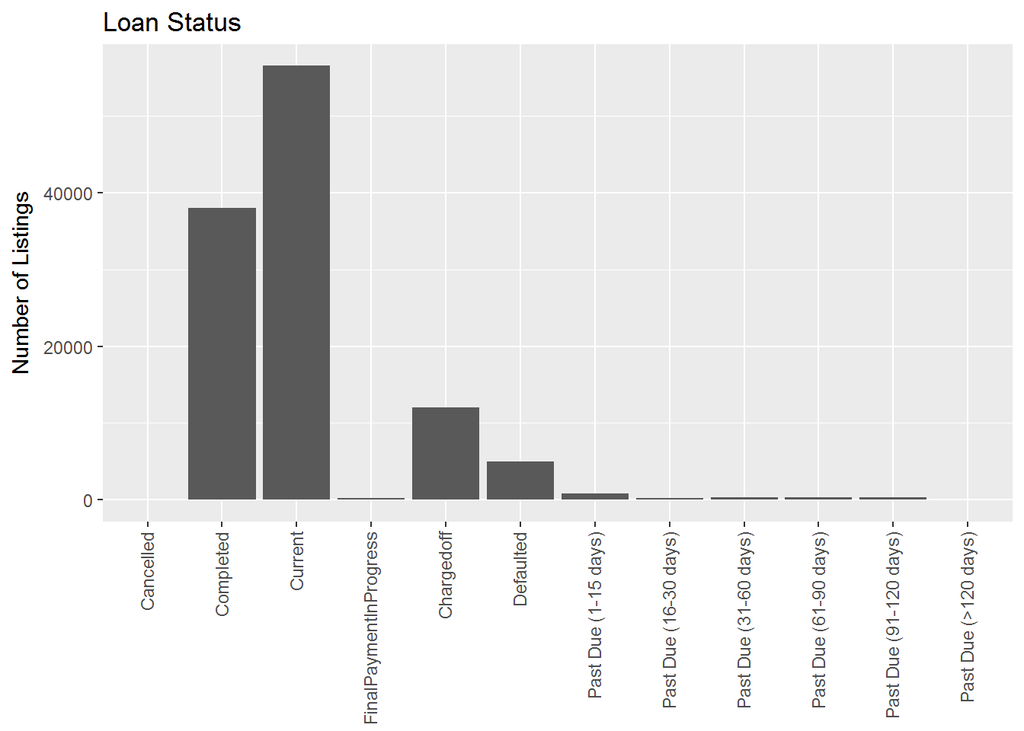

Most loans appear to be current in their payments or to sucessfully complete. It would be interesting to explore correlation between Chargedoff / Defaulted loans and ProsperRating or ProsperScore (the Prosper evaluation of a borrower’s credit worthiness).

### Listing Category

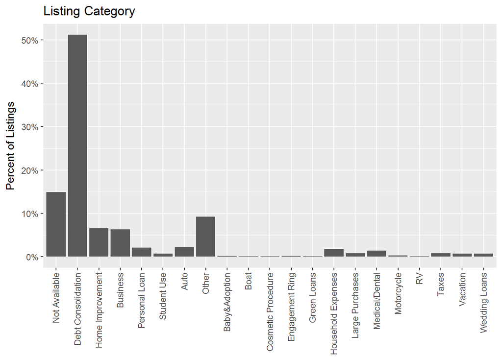

Debt consolidation is the predominant reason on Prosper for borrowing money. Over half of all listings are for Debt Consolidation. I would like to explore listing category against borrower income to determine if different levels of income tend to borrow for different reasons.

### Income Range

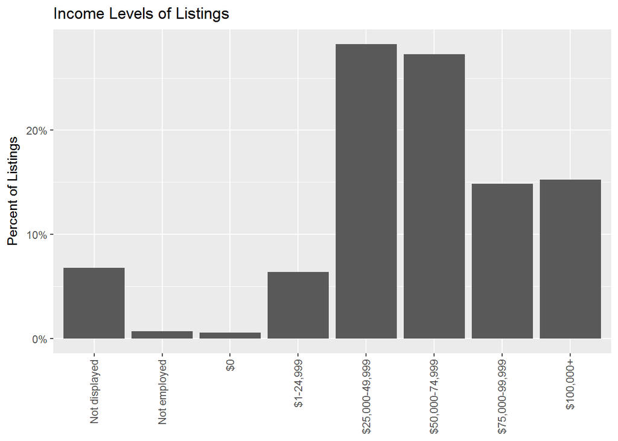

Prosper borrowers appear to be significantly more affluent than the general population of the U.S.

| Bracket | Prosper | United States |
| --- | --- | --- |
| Less than $25K | 6% | 35% |
| $25K to $50K | 28% | 36% |
| $50K to $75K | 27% | 16% |
| $75K to $100K | 15% | 6% |
| Over $100K | 15% | 7% |

(Prosper values exclude borrowers with income not displayed, who are unemployed, or who have no income. United States values are for people aged 25-64 with income.)

Prosper borrowers could be older and likely to earn more. Prosper borrowers are certainly self-selecting as the type of person who would take a loan out through an online lender. Prosper’s lending requirements could also bias to more affluent borrowers.

Reference: [Personal Income in the United States](https://en.wikipedia.org/wiki/Personal_income_in_the_United_States#Income_distribution)

### Loan Amount

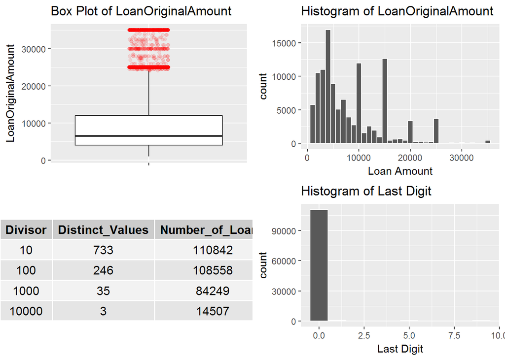

#### Loan Amount Summary Statistics

```
##    Min. 1st Qu.  Median    Mean 3rd Qu.    Max.
##    1000    4000    6500    8337   12000   35000
```

```
## # A tibble: 10 x 3
##    LoanOriginalAmount     n    pct
##                 <int> <int>  <dbl>
##  1               4000 14333 0.126
##  2              15000 12407 0.109
##  3              10000 11106 0.0975
##  4               5000  6990 0.0613
##  5               2000  6067 0.0532
##  6               3000  5749 0.0505
##  7              25000  3630 0.0319
##  8              20000  3291 0.0289
##  9               1000  3206 0.0281
## 10               2500  2992 0.0263
```

Prosper currently offers loans between $2,000 and $40,000. This data set appears to have data before that change was implemented, as loans in the set are bounded $1,000-$35,000. There is bias towards “large, round” loan amounts, indicating borrowers tend to select an amount near what they need rather than precisely. About 74% (84,000 loans of 114,000 total loans) of loans are a multiple of thousands.

$4,000 is the most commonly borrowed amount. I’m curious if the amount is also associated with a specific type of purchase (other than debt consolidation). $15,000 and $10,000 are also frequently occuring amounts. These top three account for one-third of all loans, and the top 10 loan amounts account for 61%.

Loan amounts skew right, which is typical of a personal income distribution, and I would expect loan amount to have a positive correlation with borrower income.

### Defaults by Cycle

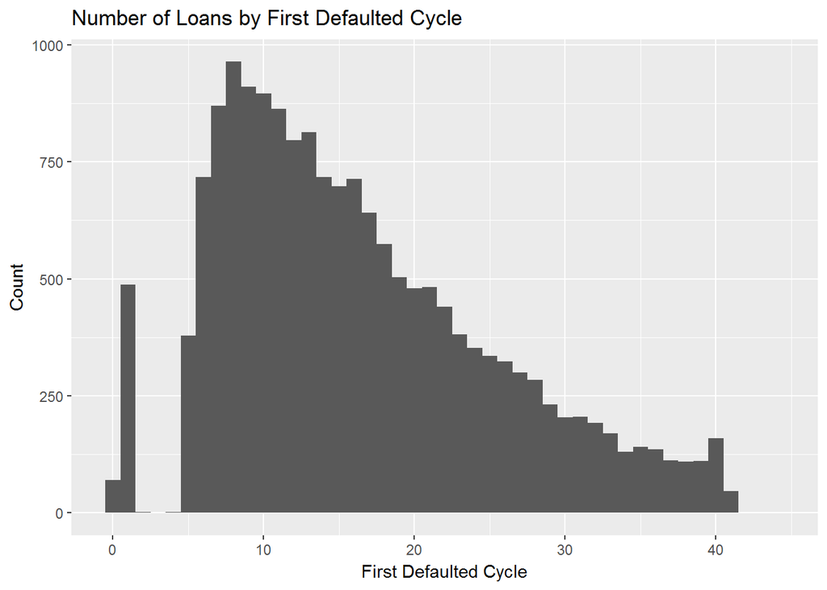

*Defaults by Cycle, Deciles*

```
##   0%  10%  20%  30%  40%  50%  60%  70%  80%  90% 100%
##    0    7    8   10   12   14   17   20   24   30   44
```

Of loans that enter default, 40% do so within 12 billing cycles. 2.8% of defaults occur in cycle 1. Cycle 8 is the single largest cycle for defaults, accounting for 5.7% of defaults. After cycle 8, the number of defaults gradually declines.

### Median Loan Amount by State

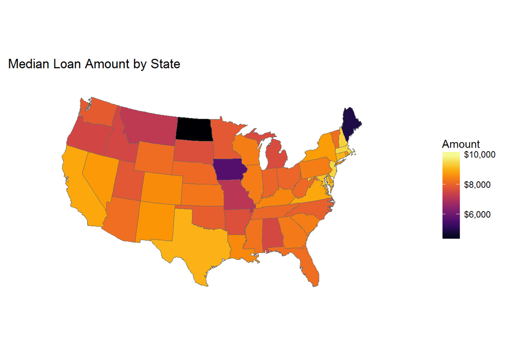

I would expect that average loan amount and median income by state would be positively correlated. This is the case in some states, such as California, Texas, and much of the northeast, but does not hold true in many other areas.

For instance, North Dakota has a relatively high median income, but comparatively low average loan value. Conversely, Louisiana has median income comparable to other gulf states, but higher average loan values.

This comparison is not rigorous, and I don’t expect to dig in to it further in this analysis, but it is an interesting map.

Reference: [Census: Median household income, 2012-2016](https://www.census.gov/quickfacts/fact/map/US/INC110216)

# Univariate Analysis

The Prosper data set is well-structured with loan observations on each row and many interesting variables in columns. There is enough information to determine if data Prosper collects is sufficient to determine credit risk and how predictive Prosper’s model is of repayment.

I performed slight cleanup on the data to:

- convert loan listing category and loan term from numeric to factors.
- add informational boolean values to high and low loan value outliers.
- simplify handling of datetimes.
- simplify column names.

Other than the above, I performed no adjustment to underlying data values.

For each plot above, I provided interesting findings about the individual variables I explored. I intend to explore a few relationships further:

- relationship between Prosper rating / score of creditworthiness and the  
  default rate
- reason for borrowing money against borrower income level; are reasons  
  consistent or varied?
- loan amount vs. income

# Bivariate Plots

### Correlation Matrix

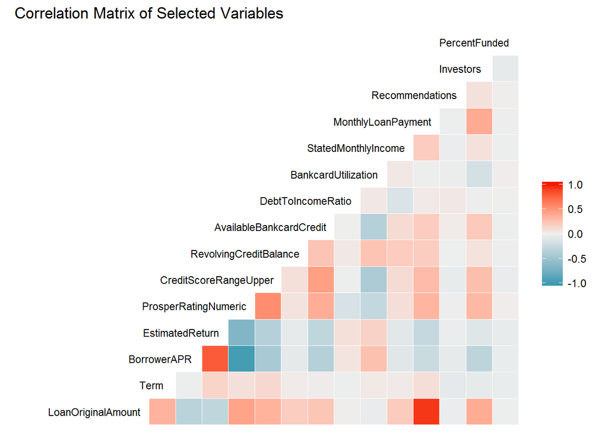

Before creating bivariate plots of the variables I found interesting through univariate analysis, I decided to create a Pearson correlation matrix to uncover potentially interesting relationships that might exist. Some relationships are unsurprising, such as Prosper rating being positively correlated with credit score (higher is better in both cases) and negatively correlated with borrower APR (better rated borrowers get lower rates). I will also explore why estimated returns are negatively correlated with loan amount and Prosper rating.

### Charge Off Rate by Prosper Rating

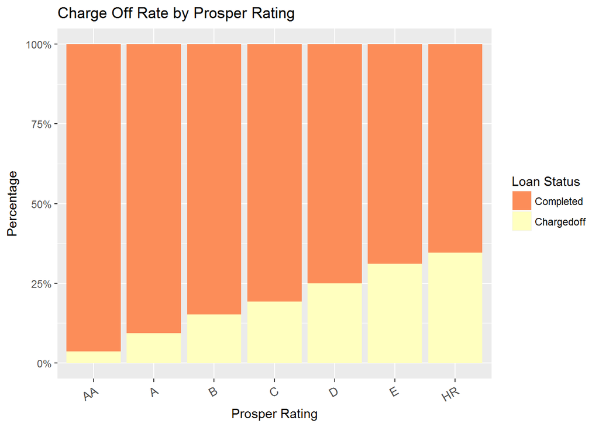

To validate my assumption that lower Prosper ratings have higher Charge Off rates, I plot the percentage of loans that have entered a final state of ‘Completed’ or ‘Charged Off’. The result is as expected. Risk of charge off steadily increases as rating decreases.

### Borrower APR and Estimated Return

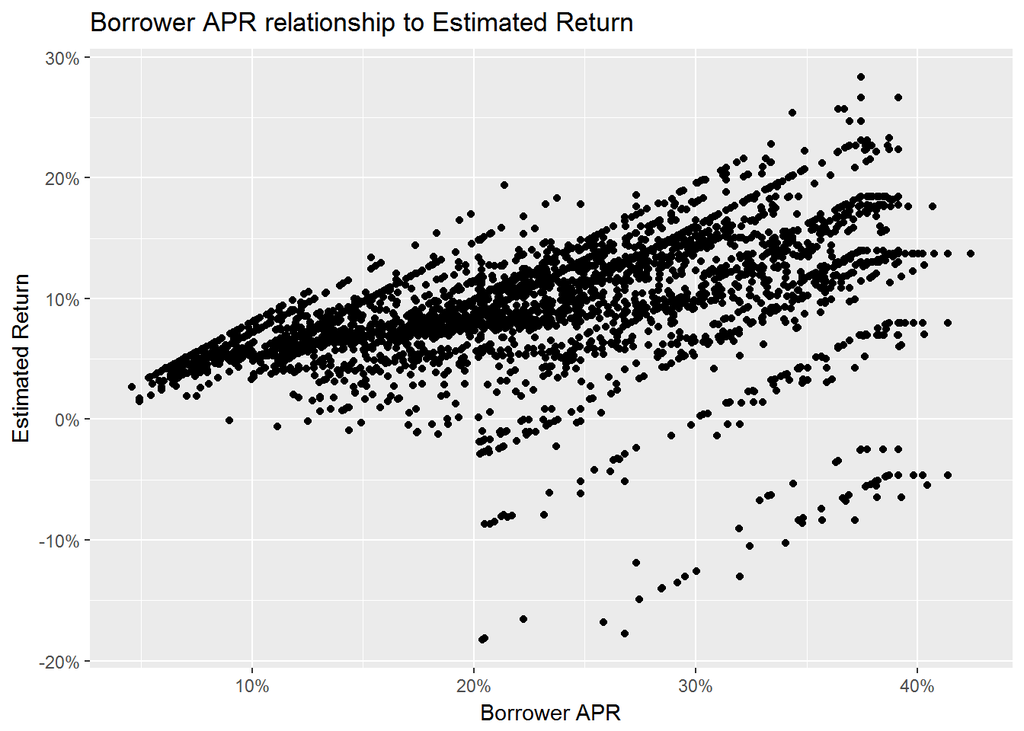

Estimated returns are strongly positively correlated to borrower APR. APRs below 20% have almost entirely positive estimated returns, while APRs above 20% have clusters of positive and negative estimated returns.

The shape of this data leads me to hypothesize that the groupings are influenced by another variable. I will further refine this plot in the multivariate section.

### Estimated Returns by Prosper Rating

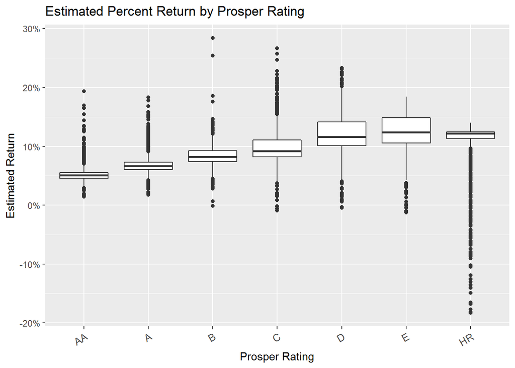

This corroborates the negative correlation between higher (better) Prosper rating and estimated percent return. I suspect this will show up in the multivariate plot of return, APR, and rating as discussed above. As we look at lower rating tranches, median estimated return increases, estimated return shows wider variation, and among the highest risk ratings, downside risk increases substantially.

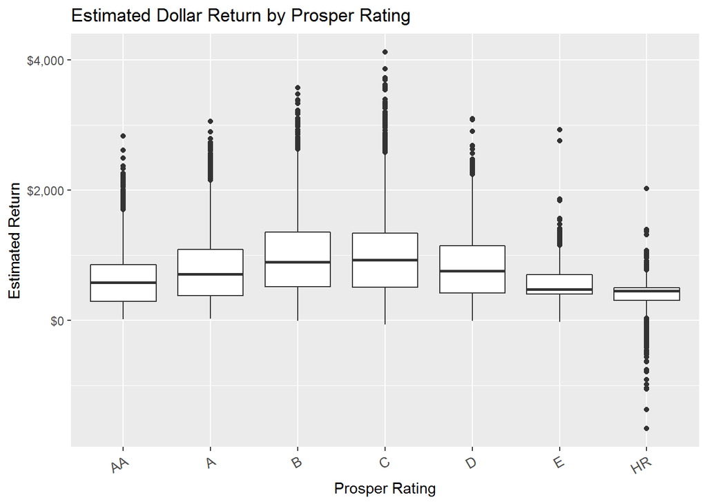

In dollar terms, the high risk tranche carries the most risk of negative returns. B and C ratings have a good balance of highest return and risk. I expect the lower dollar return to E and HR ratings are related to the loan amounts they are able to request.

### Loan Amount by Prosper Rating

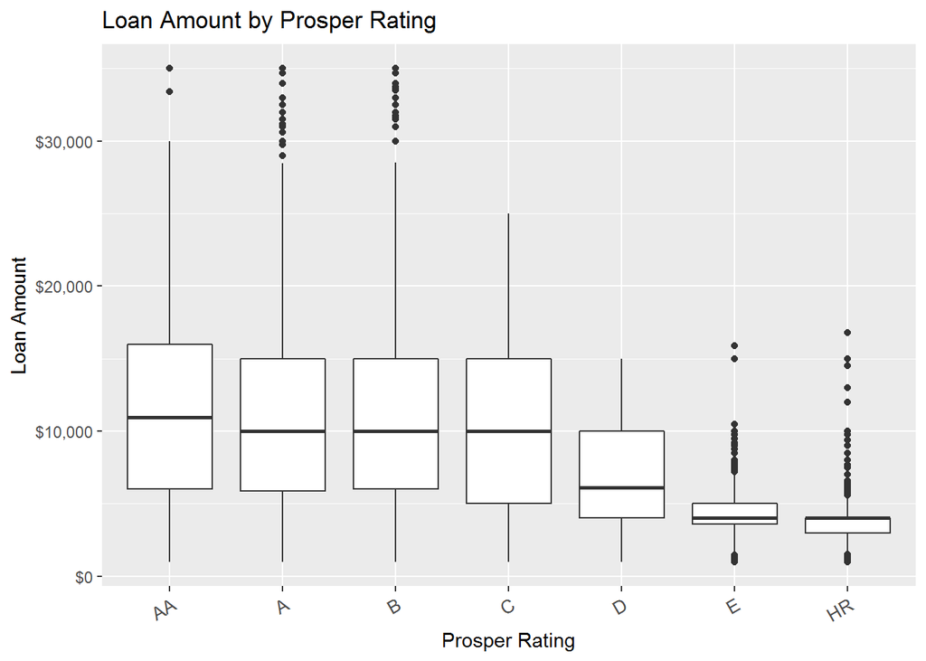

E and HR rated borrowers have median loan amounts less than half that of AA-C rated borrowers. The median loan amount and inter-quartile ranges of AA-C rated borrowers are all very similar. This makes sense because it is likely they are borrowing money for reasons unrelated directly to their credit rating, but a better credit rating enables better access to money.

### Loan Amount by Income Range

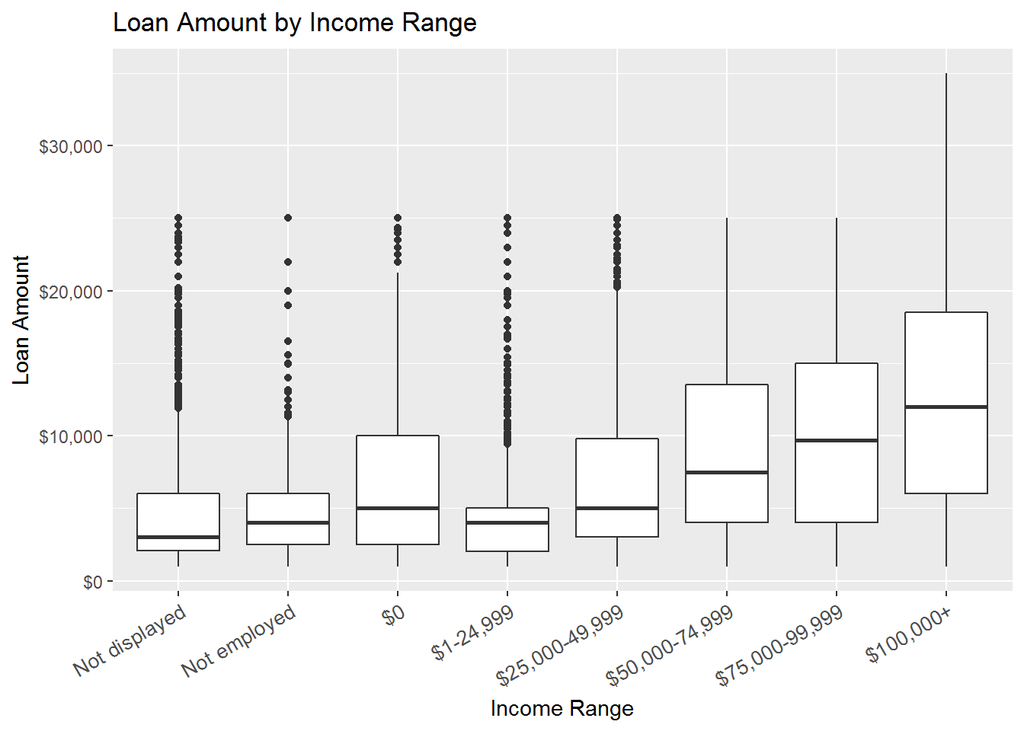

All income ranges took advantage of loans for the lowest amounts Prosper offers, but only $100K+ earners borrowed the maximum amounts. Median loan amount increases with income.

### Reason for Borrowing by Income

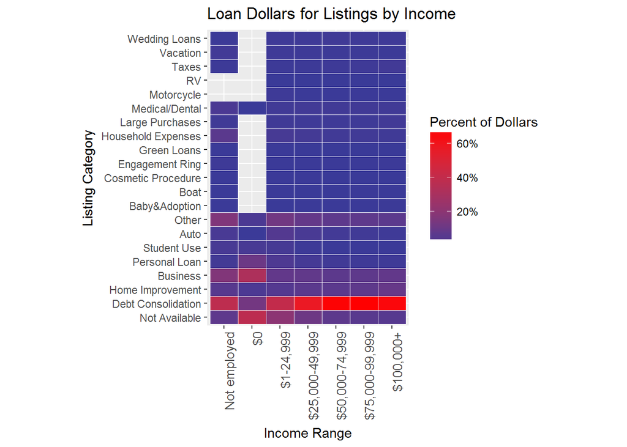

As shown above, higher earners borrow larger amounts as a whole. Why do they borrow? For each income range, the proportion of borrowing for each listing reason was calculated. The predominant reason for borrowing across almost all income ranges is Debt Consolidation. Most other reasons are near insignificant for each income range. Business borrowing is a second area revealed for borrowers with $0 stated income. This could be to start a business for someone with enough personal wealth to qualify for the loan.

### Prosper Rating by Income Range

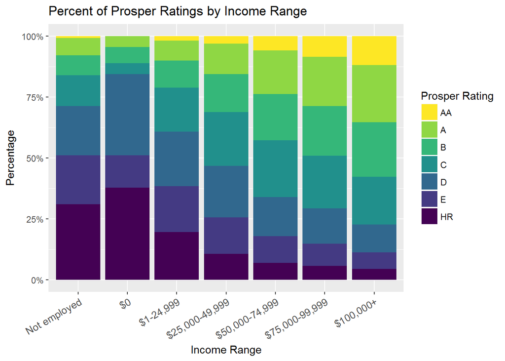

Higher incomes tend to have better ratings. The lowest rating levels quickly decrease with moderate income and the highest ratings expand. To me, this suggests that people generally want to meet their credit obligations as measured by their credit rating, and as they’re able, they do.

### Loan Amount by Term

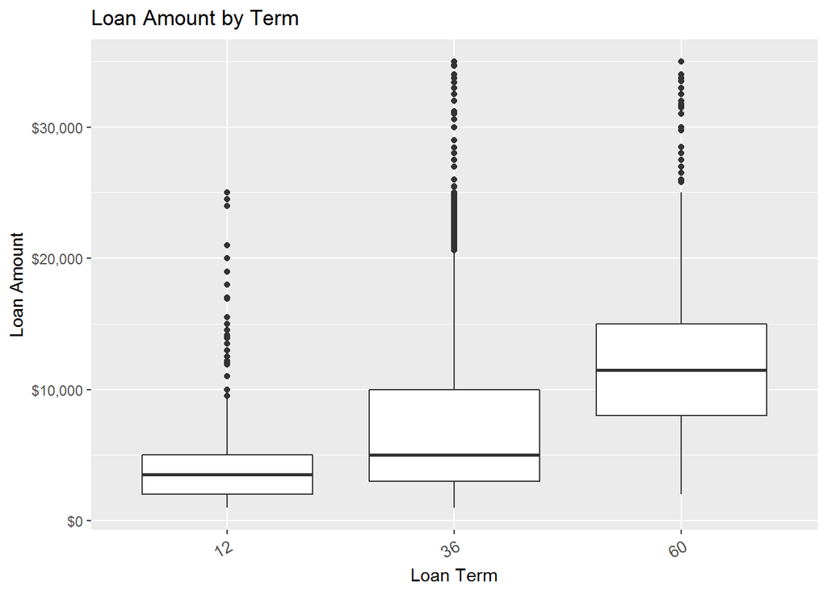

As expected, higher loan amounts are generally borrowed with longer repayment terms. I think this would be more interesting to explore with additional variables to determine if there other influences, so I will include it in multivariate analysis.

# Bivariate Analysis

My bivariate analysis began with a correlation matrix to uncover surpsising relationships. Most relationships were expected – variables commonly associated with credit worthiness (credit score, credit balances available and utilized, debt to income ratio, income) were well correlated with Prosper’s ratings. I chose to explore how investor returns were negatively correlated with loan amount and Propser rating.

Estimated return includes interest, collected late fees, and principal loss due to default. My own findings corroborate Prosper’s self-published [investor information](https://www.prosper.com/invest): higher ratings yield lower returns due to lower interest rate. Lower ratings have higher percentage returns until the high risk group, which has significant prospects of negative return.

Also of interest was the stability of reason for borrowing. Debt consolidation was near universal as a predominant reason for taking a loan, and that percentage of borrowing increased with income.

Next, I plan to explore more about:

- the relationship of borrower APR and estimated return.
- loan amounts by term length.

# Multivariate Plots Section

### Borrowing Behavior

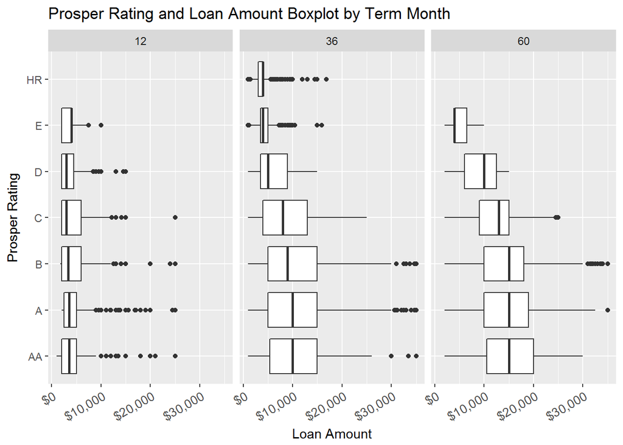

When compared to the bivariate analysis of Rating and Loan Amount above, we see the same general trend of larger loan amount being borrowed for longer terms. Some additional characteristics of the data emerge:

- High Risk borrowers have only 36-month terms. I’m unaware if this is due to a Prosper credit rating policy or due to other general offer terms.
- Borrowers across all risk groups borrowed similar amounts in 12-month terms.
- AA, A, and B groups borrow similar median amounts across all terms.

### Estimated Return and APR by Rating and Loan Amount

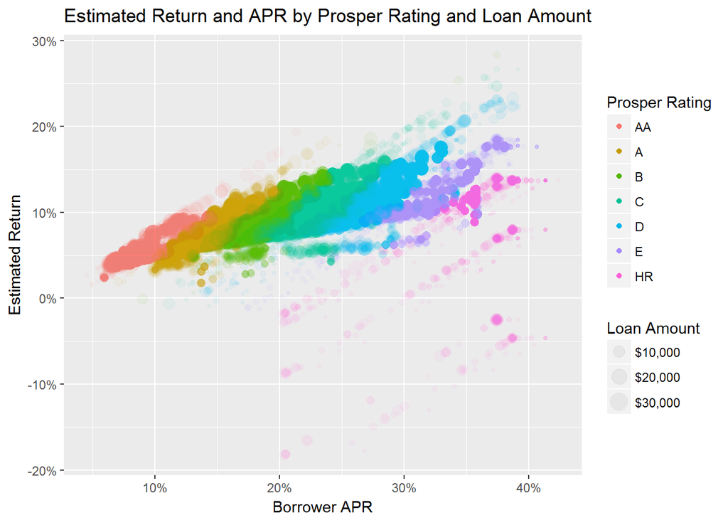

As in the bivariate analysis, clear positive correlation between borrower APR and estimated return remains. Adding Prosper rating shows distinct clustering of ratings between APRs with little overlap across ratings. This plot also highlights the potential for negative returns that exists almost exclusively with high risk borrowers, and the positive yield characteristics of non-prime lending.

# Multivariate Analysis

Adding Rating and loan amount to the estimated return by APR plot highlighted the interesting relationship of credit-worthiness and risk. A borrower’s past performance on repaying obligations appears to be more indicative of future performance than what the amount of a given loan is.

The interaction of Prosper rating, loan amount, and term was surprising. I expected to see loan term length generally increase with borrowed amount, but it was intersting how consistently similar amounts were borrowed for similar length of times across several Prosper ratings.

# Final Plots and Summary

### Defaults by Cycle

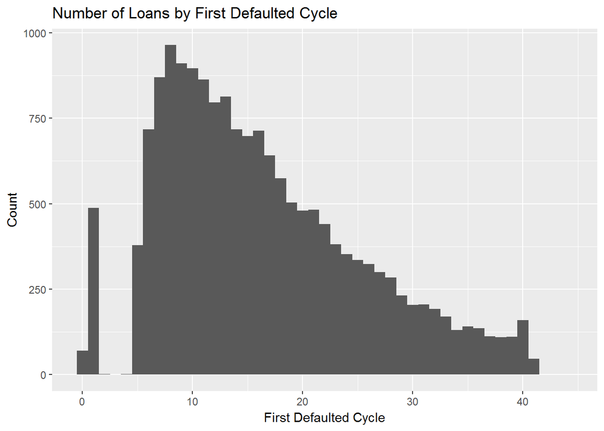

### Reason for Borrowing by Income

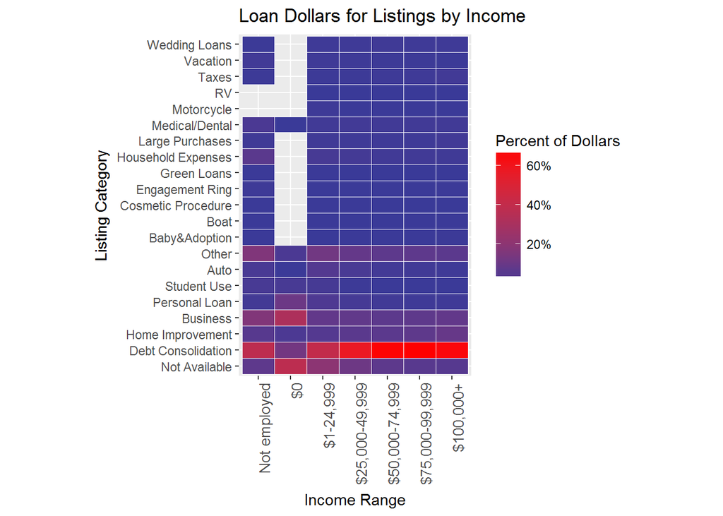

Across income ranges, people borrow money for substantially similar reasons on Prosper.

### Prosper Rating by Income Range

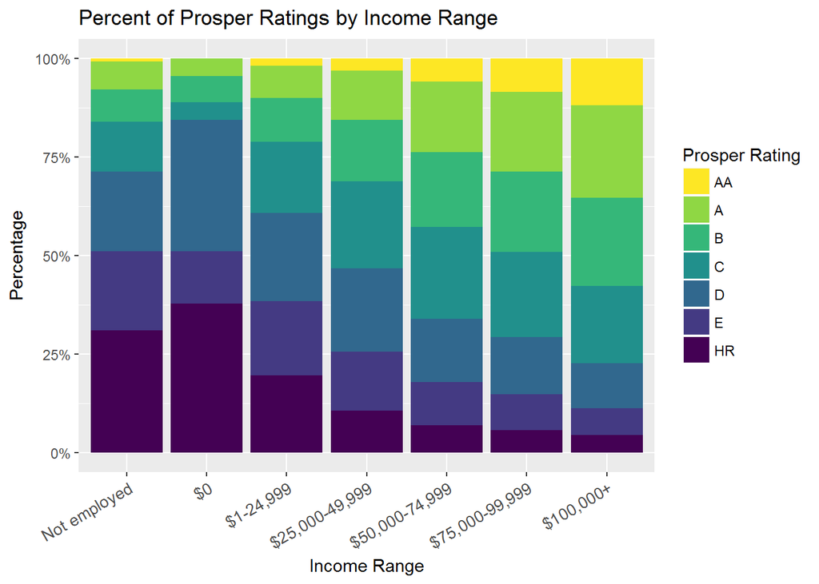

Borrowers with higher incomes tend to have better Prosper ratings.

# Reflection

Overall, it was interesting spending so much time learning R, which seems to be incredibly powerful and complex with many ways to do things that aren’t always completely intuitive.

Exploring the Prosper data set was interesting. One of the best and worst things about choosing this data set was the sheer volume of variables that were available. It might have been easier to focus if there weren’t so many choices, or if I knew there was a particular feature I was looking for. However, I learned a lot!

In the future, it would be interesting to measure the actual return of completed loans against the expected return to see how well Prosper’s system helps investors mitigate risk and maximize returns.